# DESeq_libraries8-11

# Make heatmaps of the two lists of count datas

Set Trinity_ID as row names:

```r
rownames(inftempdegs_counts_match) <- inftempdegs_counts_match$Trinity_ID #set Trinity IDs as rownames
inftempdegs_counts_match.heatmap <- inftempdegs_counts_match[,-1] #remove redundant column
head(inftempdegs_counts_match.heatmap)
```

```
##                          uninfected_cold infected_cold uninfected_warm
## TRINITY_DN83943_c0_g1_i4               0           322              18
## TRINITY_DN7721_c0_g2_i1                0            39               0
## TRINITY_DN4517_c0_g1_i3                0            89               0
## TRINITY_DN8440_c0_g1_i1                0            54               0
## TRINITY_DN22802_c0_g1_i1               0            45               0
## TRINITY_DN13344_c0_g1_i1               0            43               0
##                          infected_warm  baseMean log2FoldChange    lfcSE
## TRINITY_DN83943_c0_g1_i4           355 173.62895       6.337656 1.135067
## TRINITY_DN7721_c0_g2_i1             87  30.54891       8.381215 2.447986
## TRINITY_DN4517_c0_g1_i3             71  40.74864       8.817579 2.240947
## TRINITY_DN8440_c0_g1_i1            190  58.09152       9.185782 2.042887
## TRINITY_DN22802_c0_g1_i1           134  42.88320       8.801895 2.211291
## TRINITY_DN13344_c0_g1_i1           101  34.83516       8.559740 2.349419
##                              stat      pvalue        padj
## TRINITY_DN83943_c0_g1_i4 5.583506 2.36000e-08 0.000055800
## TRINITY_DN7721_c0_g2_i1  3.423718 6.17706e-04 0.038703367
## TRINITY_DN4517_c0_g1_i3  3.934756 8.33000e-05 0.010312842
## TRINITY_DN8440_c0_g1_i1  4.496470 6.91000e-06 0.002315106
## TRINITY_DN22802_c0_g1_i1 3.980433 6.88000e-05 0.009044179
## TRINITY_DN13344_c0_g1_i1 3.643343 2.69120e-04 0.021712067
```

Pull out just the sample count data:

```r
inftempdegs_counts_match.heatmap <- select(inftempdegs_counts_match.heatmap, uninfected_cold, infected_cold, uninfected_warm, infected_warm)
head(inftempdegs_counts_match.heatmap)
```

```
##                          uninfected_cold infected_cold uninfected_warm
## TRINITY_DN83943_c0_g1_i4               0           322              18
## TRINITY_DN7721_c0_g2_i1                0            39               0
## TRINITY_DN4517_c0_g1_i3                0            89               0
## TRINITY_DN8440_c0_g1_i1                0            54               0
## TRINITY_DN22802_c0_g1_i1               0            45               0
## TRINITY_DN13344_c0_g1_i1               0            43               0
##                          infected_warm
## TRINITY_DN83943_c0_g1_i4           355
## TRINITY_DN7721_c0_g2_i1             87
## TRINITY_DN4517_c0_g1_i3             71
## TRINITY_DN8440_c0_g1_i1            190
## TRINITY_DN22802_c0_g1_i1           134
## TRINITY_DN13344_c0_g1_i1           101
```

Going to remove all rows that have “0” for all samples:

```r
noz_inftempdegs_counts_match.heatmap <- inftempdegs_counts_match.heatmap[rowSums(inftempdegs_counts_match.heatmap[, -1] >0) !=0, ]
head(noz_inftempdegs_counts_match.heatmap)
```

```
##                          uninfected_cold infected_cold uninfected_warm
## TRINITY_DN83943_c0_g1_i4               0           322              18
## TRINITY_DN7721_c0_g2_i1                0            39               0
## TRINITY_DN4517_c0_g1_i3                0            89               0
## TRINITY_DN8440_c0_g1_i1                0            54               0
## TRINITY_DN22802_c0_g1_i1               0            45               0
## TRINITY_DN13344_c0_g1_i1               0            43               0
##                          infected_warm
## TRINITY_DN83943_c0_g1_i4           355
## TRINITY_DN7721_c0_g2_i1             87
## TRINITY_DN4517_c0_g1_i3             71
## TRINITY_DN8440_c0_g1_i1            190
## TRINITY_DN22802_c0_g1_i1           134
## TRINITY_DN13344_c0_g1_i1           101
```

```r
heatmapPurpleOrange <- RColorBrewer::brewer.pal(11, "PuOr")
```

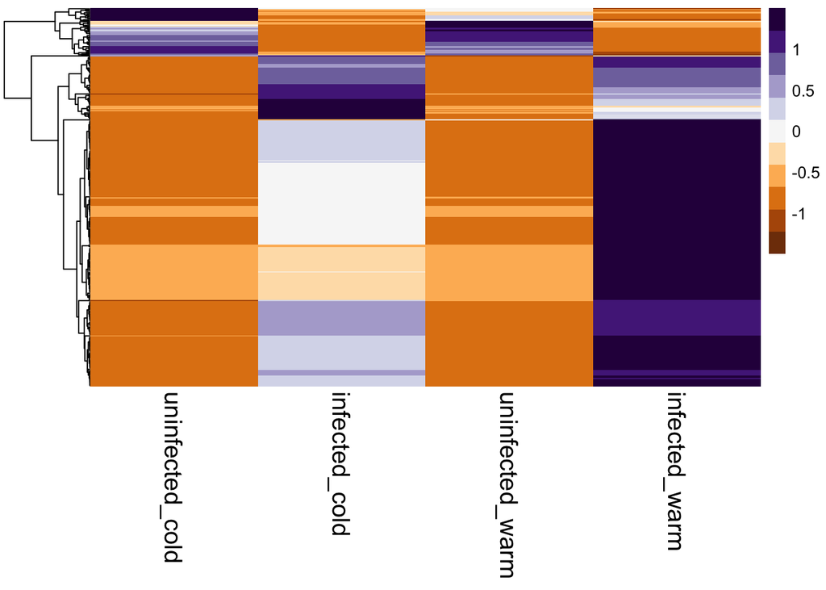

```r
pheatmap(noz_inftempdegs_counts_match.heatmap, scale = "row", cluster_row = TRUE, cluster_cols = FALSE, clustering_distance_rows = "euclidean", clustering_method = "average", show_rownames = FALSE, show_colnames = TRUE, treeheight_col = 80, legend = TRUE, color = heatmapPurpleOrange, fontsize_col = 15, fontsize_row = 12)
```

## Heatmap of counts from 123 list (contrast of temperatures from infection comparison taking temperature into account)

Set Trinity_ID as row names:

```r
rownames(contrtempdegs_counts_match) <- contrtempdegs_counts_match$Trinity_ID #set Trinity IDs as rownames
contrtempdegs_counts_match.heatmap <- contrtempdegs_counts_match[,-1] #remove redundant column
head(contrtempdegs_counts_match.heatmap)
```

```
##                          uninfected_cold infected_cold uninfected_warm
## TRINITY_DN12600_c0_g1_i2               0             0             108
## TRINITY_DN12397_c1_g1_i1              67           148               0
## TRINITY_DN428_c0_g1_i6               371           761            2054
## TRINITY_DN10286_c0_g1_i1              17            39             221
## TRINITY_DN4702_c0_g1_i2                0             0             212
## TRINITY_DN1091_c0_g1_i16             182            50               0
##                          infected_warm   baseMean log2FoldChange     lfcSE
## TRINITY_DN12600_c0_g1_i2           109   48.25267       8.918859 2.1376058
## TRINITY_DN12397_c1_g1_i1             0   58.71905      -9.373273 2.0352048
## TRINITY_DN428_c0_g1_i6            2161 1246.63027       1.699913 0.4042303
## TRINITY_DN10286_c0_g1_i1           397  153.54567       3.234433 0.8644983
## TRINITY_DN4702_c0_g1_i2            164   83.37100       9.700602 1.8816717
## TRINITY_DN1091_c0_g1_i16             0   62.10922      -9.323208 2.0112179
##                               stat      pvalue        padj
## TRINITY_DN12600_c0_g1_i2  4.172359 0.000030100 0.009465915
## TRINITY_DN12397_c1_g1_i1 -4.605567 0.000004110 0.002472057
## TRINITY_DN428_c0_g1_i6    4.205308 0.000026100 0.008501710
## TRINITY_DN10286_c0_g1_i1  3.741399 0.000182999 0.032322199
## TRINITY_DN4702_c0_g1_i2   5.155311 0.000000253 0.000330265
## TRINITY_DN1091_c0_g1_i16 -4.635603 0.000003560 0.002270095
```

Pull out just the sample count data:

```r
contrtempdegs_counts_match.heatmap <- select(contrtempdegs_counts_match.heatmap, uninfected_cold, infected_cold, uninfected_warm, infected_warm)
head(contrtempdegs_counts_match.heatmap)
```

```
##                          uninfected_cold infected_cold uninfected_warm
## TRINITY_DN12600_c0_g1_i2               0             0             108
## TRINITY_DN12397_c1_g1_i1              67           148               0
## TRINITY_DN428_c0_g1_i6               371           761            2054
## TRINITY_DN10286_c0_g1_i1              17            39             221
## TRINITY_DN4702_c0_g1_i2                0             0             212
## TRINITY_DN1091_c0_g1_i16             182            50               0
##                          infected_warm
## TRINITY_DN12600_c0_g1_i2           109
## TRINITY_DN12397_c1_g1_i1             0
## TRINITY_DN428_c0_g1_i6            2161
## TRINITY_DN10286_c0_g1_i1           397
## TRINITY_DN4702_c0_g1_i2            164
## TRINITY_DN1091_c0_g1_i16             0
```

Going to remove all rows that have “0” for all samples:

```r
noz_contrtempdegs_counts_match.heatmap <- contrtempdegs_counts_match.heatmap[rowSums(contrtempdegs_counts_match.heatmap[, -1] >0) !=0, ]
head(noz_contrtempdegs_counts_match.heatmap)
```

```
##                          uninfected_cold infected_cold uninfected_warm
## TRINITY_DN12600_c0_g1_i2               0             0             108
## TRINITY_DN12397_c1_g1_i1              67           148               0
## TRINITY_DN428_c0_g1_i6               371           761            2054
## TRINITY_DN10286_c0_g1_i1              17            39             221
## TRINITY_DN4702_c0_g1_i2                0             0             212
## TRINITY_DN1091_c0_g1_i16             182            50               0
##                          infected_warm
## TRINITY_DN12600_c0_g1_i2           109
## TRINITY_DN12397_c1_g1_i1             0
## TRINITY_DN428_c0_g1_i6            2161
## TRINITY_DN10286_c0_g1_i1           397
## TRINITY_DN4702_c0_g1_i2            164
## TRINITY_DN1091_c0_g1_i16             0
```

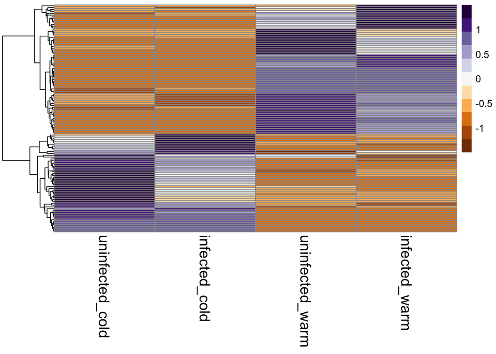

```r
pheatmap(noz_contrtempdegs_counts_match.heatmap, scale = "row", cluster_row = TRUE, cluster_cols = FALSE, clustering_distance_rows = "euclidean", clustering_method = "average", show_rownames = FALSE, show_colnames = TRUE, treeheight_col = 80, legend = TRUE, color = heatmapPurpleOrange, fontsize_col = 15, fontsize_row = 12)
```

# Get the genes that correspond with the clusters (the purple ones –> higher expression)

## Gene clusters from heatmap comparing infection status taking temperature into account (first heatmap)

Set the heatmap as an object called ‘results’:

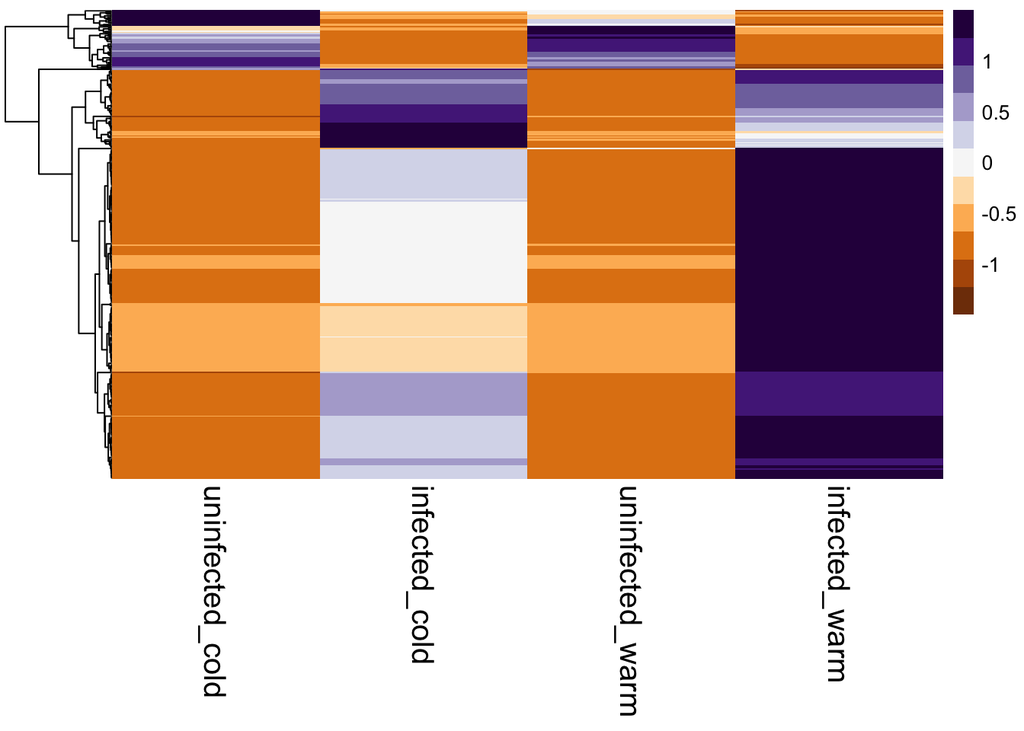

```r
results <- pheatmap(noz_inftempdegs_counts_match.heatmap, scale = "row", cluster_row = TRUE, cluster_cols = FALSE, clustering_distance_rows = "euclidean", clustering_method = "average", show_rownames = FALSE, show_colnames = TRUE, treeheight_col = 80, legend = TRUE, color = heatmapPurpleOrange, fontsize_col = 15, fontsize_row = 12)
```

extract 4 clusters.

```r
inftemp.clust <- cbind(noz_inftempdegs_counts_match.heatmap,
                   cluster = cutree(results$tree_row,
                                     k = 4))
head(inftemp.clust)
```

```
##                          uninfected_cold infected_cold uninfected_warm
## TRINITY_DN83943_c0_g1_i4               0           322              18
## TRINITY_DN7721_c0_g2_i1                0            39               0
## TRINITY_DN4517_c0_g1_i3                0            89               0
## TRINITY_DN8440_c0_g1_i1                0            54               0
## TRINITY_DN22802_c0_g1_i1               0            45               0
## TRINITY_DN13344_c0_g1_i1               0            43               0
##                          infected_warm cluster
## TRINITY_DN83943_c0_g1_i4           355       1
## TRINITY_DN7721_c0_g2_i1             87       1
## TRINITY_DN4517_c0_g1_i3             71       1
## TRINITY_DN8440_c0_g1_i1            190       1
## TRINITY_DN22802_c0_g1_i1           134       1
## TRINITY_DN13344_c0_g1_i1           101       1
```

Cluster 1 –> infected_warm  
Cluster 2 –> uninfected_cold  
Cluster 3 –> uninfected_warm  
Cluster 4 –> infected_cold

## Gene clusters from heatmap contrasting temperatures from the comparison infection status taking temperature into account (second heatmap)

Set the heatmap as an object called ‘results2’:

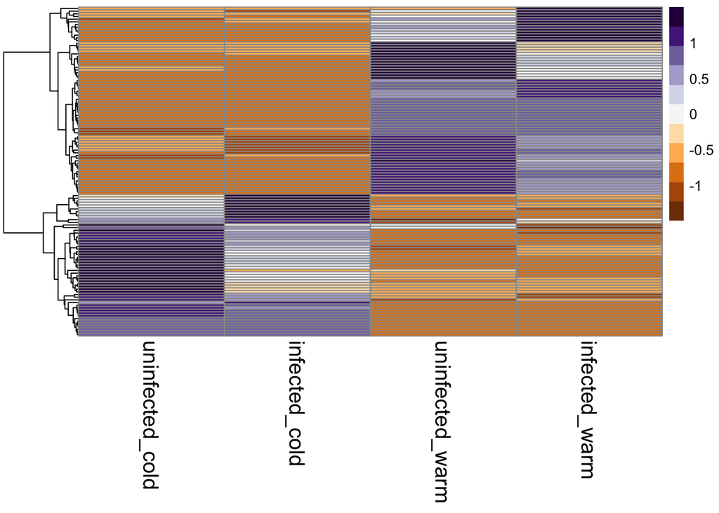

```r
results2 <- pheatmap(noz_contrtempdegs_counts_match.heatmap, scale = "row", cluster_row = TRUE, cluster_cols = FALSE, clustering_distance_rows = "euclidean", clustering_method = "average", show_rownames = FALSE, show_colnames = TRUE, treeheight_col = 80, legend = TRUE, color = heatmapPurpleOrange, fontsize_col = 15, fontsize_row = 12)
```

extract 4 clusters.

```r
contrasttemp.clust <- cbind(noz_contrtempdegs_counts_match.heatmap,
                   cluster = cutree(results2$tree_row,
                                     k = 4))
head(contrasttemp.clust)
```

```
##                          uninfected_cold infected_cold uninfected_warm
## TRINITY_DN12600_c0_g1_i2               0             0             108
## TRINITY_DN12397_c1_g1_i1              67           148               0
## TRINITY_DN428_c0_g1_i6               371           761            2054
## TRINITY_DN10286_c0_g1_i1              17            39             221
## TRINITY_DN4702_c0_g1_i2                0             0             212
## TRINITY_DN1091_c0_g1_i16             182            50               0
##                          infected_warm cluster
## TRINITY_DN12600_c0_g1_i2           109       1
## TRINITY_DN12397_c1_g1_i1             0       2
## TRINITY_DN428_c0_g1_i6            2161       1
## TRINITY_DN10286_c0_g1_i1           397       3
## TRINITY_DN4702_c0_g1_i2            164       1
## TRINITY_DN1091_c0_g1_i16             0       4
```